# Lab 3 : Pandas, sklearn and hyperparameter tuning

We begin by importing all necessary dependencies

```python
import numpy as np
import pandas as pd

# Increase Graph Resolution
%config InlineBackend.figure_format = 'retina'
```

We set the seed to make sure that our random values are the same

```python
# Defining a random_state to ensure reproducibility of the results
np.random.seed(42)
```

# Part 1

#### In the first part, we consider a dataset where the goal is to predict the number of passengers on a given flight.

# Question 1

#### 1) What kind of problem is it ? Regression of classification ? Supervised or unsupervised ?

- **Regression vs. Classification**: At first glance, this seems to be a regression problem due to the numerical nature of the prediction target, which is a real number. It's worth noting though, that if the number of passengers were restricted to specific discrete values (e.g., 0-50, 51-100, 101-150 etc.), the problem could also be framed as a classification task where the passenger count is considered in separate, discrete classes. However, in this scenario, where passenger counts can vary more continuously and aren't confined to a set of fixed values, treating it as a regression problem is more appropriate.
- **Supervised vs. Unsupervised**: The task requires us to predict an outcome (number of passengers) based on input variables. This implies that there is a target variable to predict, which is a hallmark of supervised learning. Unsupervised learning would involve finding patterns or structures in the data without the guidance of a specific target variable.

# Question 2

#### 2) Load the training data from Moodle (train.csv.bz2 ; bz2 is a compression format, pandas can decompress it itself). The target variable is called log_PAX. Do a quick inspection of the dataset. What are the types of the columns ?

```python
# Load the dataset
data = pd.read_csv('train.csv.bz2', compression='bz2')
```

```python
data.head()
```

|  | DateOfDeparture | Departure | Arrival | WeeksToDeparture | log_PAX | std_wtd |
| --- | --- | --- | --- | --- | --- | --- |
| 0 | 2012-06-19 | ORD | DFW | 12.875000 | 12.331296 | 9.812647 |
| 1 | 2012-09-10 | LAS | DEN | 14.285714 | 10.775182 | 9.466734 |
| 2 | 2012-10-05 | DEN | LAX | 10.863636 | 11.083177 | 9.035883 |
| 3 | 2011-10-09 | ATL | ORD | 11.480000 | 11.169268 | 7.990202 |
| 4 | 2012-02-21 | DEN | SFO | 11.450000 | 11.269364 | 9.517159 |

```python
# Display basic info about the dataset
data.info()
```

```
<class 'pandas.core.frame.DataFrame'>
RangeIndex: 8902 entries, 0 to 8901
Data columns (total 6 columns):
 #   Column            Non-Null Count  Dtype
---  ------            --------------  -----
 0   DateOfDeparture   8902 non-null   object
 1   Departure         8902 non-null   object
 2   Arrival           8902 non-null   object
 3   WeeksToDeparture  8902 non-null   float64
 4   log_PAX           8902 non-null   float64
 5   std_wtd           8902 non-null   float64
dtypes: float64(3), object(3)
memory usage: 417.4+ KB
```

**What are the types of the columns ?**

- The DateOfDeparture, Departure, and Arrival columns are of type object, which usually means they are strings or mixed types. These columns likely contain categorical data, with DateOfDeparture probably formatted as a date string, and Departure and Arrival representing airport codes.
- The WeeksToDeparture, log_PAX, and std_wtd columns are all floating-point numbers (float64), indicating numerical data.

```python
import ydata_profiling

#data.profile_report()
```

# Question 3

#### 3) Convert dates to proper dates. Create new integers columns containing respectively the day, the week, the month, the year, a binary variable indicating if this is a work day or holiday (in the US calendar).

```python
# Convert 'DateOfDeparture' to datetime format
data['DateOfDeparture'] = pd.to_datetime(data['DateOfDeparture'])
```

```python
# Create columns for day, week, month, and year from 'DateOfDeparture'
data['Departure_Day'] = data['DateOfDeparture'].dt.day
data['Departure_Week'] = data['DateOfDeparture'].dt.isocalendar().week
data['Departure_Month'] = data['DateOfDeparture'].dt.month
data['Departure_Year'] = data['DateOfDeparture'].dt.year

# Create a column for the weekday (Monday=0, Sunday=6)
data['Weekday'] = data['DateOfDeparture'].dt.dayofweek
```

```python
from pandas.tseries.holiday import USFederalHolidayCalendar

# Define the range of holidays in the dataset
cal = USFederalHolidayCalendar()
holidays = cal.holidays(start=data['DateOfDeparture'].min(), end=data['DateOfDeparture'].max())

# Create a binary column for holidays
data['is_Holiday'] = data['DateOfDeparture'].isin(holidays).astype(int)
```

```python
# Create a binary column for workdays: Workday if it's a weekday (Mon-Fri) and not a holiday
data['is_Workday'] = ((data['Weekday'] < 5) & ~data['is_Holiday']).astype(int)
```

```python
data.head()
```

|  | DateOfDeparture | Departure | Arrival | WeeksToDeparture | log_PAX | std_wtd | Departure_Day | Departure_Week | Departure_Month | Departure_Year | Weekday | is_Holiday | is_Workday |
| --- | --- | --- | --- | --- | --- | --- | --- | --- | --- | --- | --- | --- | --- |
| 0 | 2012-06-19 | ORD | DFW | 12.875000 | 12.331296 | 9.812647 | 19 | 25 | 6 | 2012 | 1 | 0 | 1 |
| 1 | 2012-09-10 | LAS | DEN | 14.285714 | 10.775182 | 9.466734 | 10 | 37 | 9 | 2012 | 0 | 0 | 1 |
| 2 | 2012-10-05 | DEN | LAX | 10.863636 | 11.083177 | 9.035883 | 5 | 40 | 10 | 2012 | 4 | 0 | 1 |
| 3 | 2011-10-09 | ATL | ORD | 11.480000 | 11.169268 | 7.990202 | 9 | 40 | 10 | 2011 | 6 | 0 | 0 |
| 4 | 2012-02-21 | DEN | SFO | 11.450000 | 11.269364 | 9.517159 | 21 | 8 | 2 | 2012 | 1 | 0 | 1 |

```python
data.info()
```

```
<class 'pandas.core.frame.DataFrame'>
RangeIndex: 8902 entries, 0 to 8901
Data columns (total 13 columns):
 #   Column            Non-Null Count  Dtype
---  ------            --------------  -----
 0   DateOfDeparture   8902 non-null   datetime64[ns]
 1   Departure         8902 non-null   object
 2   Arrival           8902 non-null   object
 3   WeeksToDeparture  8902 non-null   float64
 4   log_PAX           8902 non-null   float64
 5   std_wtd           8902 non-null   float64
 6   Departure_Day     8902 non-null   int32
 7   Departure_Week    8902 non-null   UInt32
 8   Departure_Month   8902 non-null   int32
 9   Departure_Year    8902 non-null   int32
 10  Weekday           8902 non-null   int32
 11  is_Holiday        8902 non-null   int64
 12  is_Workday        8902 non-null   int64
dtypes: UInt32(1), datetime64[ns](1), float64(3), int32(4), int64(2), object(2)
memory usage: 739.1+ KB
```

### Interpretation:

The enhanced script's transformation of the dataset revolves around the DateOfDeparture column, with a focus on extracting and categorizing date-related information:

Breakdown of the date into day, week, month, and year components. This granular approach aids in time series analysis and in uncovering seasonal trends. Identification of weekdays, offering insight into how departure dates fall in the context of a week. This is pertinent as passenger volumes may vary between weekdays and weekends. Flagging of US federal holidays, a critical element in understanding travel patterns since these holidays can markedly impact passenger volumes. Assessment of standard workdays by considering both the day of the week and holiday status, providing further nuance to the date information.

### Analysis:

The script's processing enriches the DataFrame with additional numerical features, evident in data.info(). This enhancement is strategic for machine learning applications and analytical tasks:

The separation into distinct date components (day, week, month, year) is instrumental in identifying temporal trends and patterns. The transformation of boolean data into integers readies the dataset for algorithms requiring numerical input. The script's efficiency stems from leveraging vectorized operations and built-in Pandas functions for date manipulation, ensuring rapid execution even with large datasets. Incorporation of the USFederalHolidayCalendar simplifies handling of complex holiday logic, enhancing scalability and reducing error potential. This preprocessing step effectively converts raw date data into structured, analytical features. It opens avenues for deeper insights into travel patterns related to timing and seasons, potentially leading to more accurate forecasting and pattern recognition.

*In the following block, use only numerical features.*

# Question 4

#### 4) First, select numerical features in an automated fashion (not by hand). You can for example use a list comprehension, or df.select_dtypes

```python
# Select only numerical features from the dataset
numerical_features = data.select_dtypes(include=np.number)
```

```python
# Display the first few rows of the numerical features
numerical_features.head()
```

|  | WeeksToDeparture | log_PAX | std_wtd | Departure_Day | Departure_Week | Departure_Month | Departure_Year | Weekday | is_Holiday | is_Workday |
| --- | --- | --- | --- | --- | --- | --- | --- | --- | --- | --- |
| 0 | 12.875000 | 12.331296 | 9.812647 | 19 | 25 | 6 | 2012 | 1 | 0 | 1 |
| 1 | 14.285714 | 10.775182 | 9.466734 | 10 | 37 | 9 | 2012 | 0 | 0 | 1 |
| 2 | 10.863636 | 11.083177 | 9.035883 | 5 | 40 | 10 | 2012 | 4 | 0 | 1 |
| 3 | 11.480000 | 11.169268 | 7.990202 | 9 | 40 | 10 | 2011 | 6 | 0 | 0 |
| 4 | 11.450000 | 11.269364 | 9.517159 | 21 | 8 | 2 | 2012 | 1 | 0 | 1 |

```python
# Output the data types of the selected features
numerical_features.dtypes
```

```
WeeksToDeparture    float64
log_PAX             float64
std_wtd             float64
Departure_Day         int32
Departure_Week       UInt32
Departure_Month       int32
Departure_Year        int32
Weekday               int32
is_Holiday            int64
is_Workday            int64
dtype: object
```

### Interpretation:

The `numerical_features` DataFrame has been refined to include only columns with numerical data, aligning with the requirements of most machine learning models that interpret numerical input exclusively. Notably, the `Departure_Week` column stands out with its `UInt32` data type, suitable for representing week numbers as they are inherently positive integers.

### Analysis:

The strategy of employing `select_dtypes` to isolate numerical columns is a streamlined approach, particularly advantageous in datasets with numerous features. This method circumvents the tedious and error-prone process of manual selection. By including `np.number` in the `include` parameter, the script ensures the inclusion of all numerical type variants.

However, the choice of `UInt32` for `Departure_Week`, while logically sound, may present compatibility challenges with certain machine learning frameworks that favor the more conventional `int64` type. Some libraries may not fully support unsigned integers like `UInt32`, potentially necessitating a conversion to `int64` for uniformity and broader compatibility.

With the `numerical_features` DataFrame now focused solely on numerical data, it lays the groundwork for subsequent preprocessing steps such as normalization or feature engineering. These steps are essential in preparing data for model training. The automated selection of numerical features exemplifies a best practice in data processing, enhancing both the maintainability and readability of the code.

# Question 5

#### 5) We will use the Root Mean Squared Error (RMSE) as a figure of merit (performance measure) for this prediction task. Explain how it is defined and why it is relevant here.

The Root Mean Squared Error (RMSE) measures the average magnitude of errors between predicted and actual values. It emphasizes larger errors due to the squaring operation and is defined as:

$\text{RMSE} = \sqrt{\frac{1}{n} \sum_{i=1}^{n} (y_i - \hat{y}_i)^2}$

- $n$ is the number of observations,
- $y_i$ is the actual value for the $i$-th observation, and
- $\hat{y}_i$ is the predicted value for the $i$-th observation.

It's a useful metric for understanding model accuracy in terms of the unit of prediction and for comparing different models. It is a measure of the model's prediction error and is relevant here because it gives us an idea of how far off our predictions are from the actual values on average. Here it's also relevant because we deal with a regression problem so this quadratic mean is well defined.

**Unit Consistency**: RMSE is in the same unit as the predicted variable, making it intuitively easier to interpret in the context of the data. For instance, if we are predicting the number of passengers (PAX), an RMSE of 10 means the predictions are off by 10 passengers on average.

**Comparison Across Models**: RMSE provides a convenient scale to compare the prediction errors of different models on the same dataset. The model with the lowest RMSE is generally considered to have the best fit, assuming the same dataset and the same measurement units.

**Zero Error Baseline**: An RMSE of zero indicates perfect predictions with no errors, providing a clear baseline against which to measure model performance.

# Question 6

#### 6) Do a train-test split of the data (a single one, so far. You’ll do K-fold cross validation later) and tune the max_depth parameter of a DecisionTreeRegressor. Explain briefly how this estimator does its prediction. Plot the RMSE on train and test sets as a function of this parameter.

```python
from sklearn.model_selection import train_test_split

# Define variables for features and target
X = numerical_features.drop(columns=['log_PAX'])
y = numerical_features['log_PAX']

# Split the dataset into training and testing sets
X_train, X_test, y_train, y_test = train_test_split(X, y, test_size=0.2, random_state=42)
```

```python
from sklearn.dummy import DummyRegressor
from sklearn.metrics import mean_squared_error

# Initialize and train a DummyRegressor for baseline comparison
dummy_reg = DummyRegressor(strategy='mean')
dummy_reg.fit(X_train, y_train)
y_dummy_pred = dummy_reg.predict(X_test)

# Calculate RMSE for the dummy regressor
dummy_rmse = np.sqrt(mean_squared_error(y_test, y_dummy_pred))
print(f"Dummy RMSE: {dummy_rmse:.3f}")
```

```
Dummy RMSE: 0.970
```

```python
# Tune max_depth for a DecisionTreeRegressor and track RMSE
max_depth_range = range(1, 21)
train_rmse = []
test_rmse = []
```

```python
from sklearn.tree import DecisionTreeRegressor

# Evaluate models with different depths
for depth in max_depth_range:
    tree_reg = DecisionTreeRegressor(max_depth=depth)
    tree_reg.fit(X_train, y_train)

    # Compute RMSE for both train and test sets
    train_rmse.append(np.sqrt(mean_squared_error(y_train, tree_reg.predict(X_train))))
    test_rmse.append(np.sqrt(mean_squared_error(y_test, tree_reg.predict(X_test))))
```

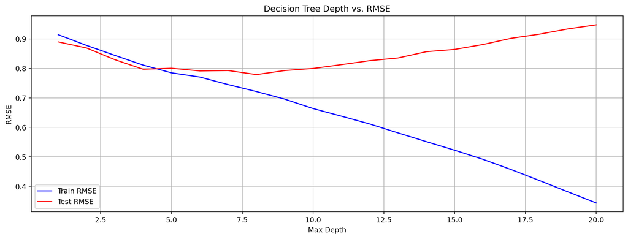

```python
import matplotlib.pyplot as plt

# Plot RMSE as a function of tree depth
fig, ax = plt.subplots(figsize=(15, 5))

ax.plot(max_depth_range, train_rmse, 'b-', label='Train RMSE')
ax.plot(max_depth_range, test_rmse, 'r-', label='Test RMSE')

plt.title('Decision Tree Depth vs. RMSE')
plt.xlabel('Max Depth')
plt.ylabel('RMSE')

plt.legend()
plt.grid()
plt.show()
```

### Interpretation of the graph:

As the depth of the tree increases, the RMSE for the training set consistently decreases. This is indicative of the model becoming more complex and fitting the training data better.

However, for the test set, the RMSE decreases initially but starts to increase as the depth goes beyond a certain point. This is a classic sign of **overfitting** where the model fits the training data too well, capturing noise in addition to the underlying data distribution. Consequently, its performance on unseen data (test set) gets worse.

**The point at which the test RMSE starts to increase represents the threshold where the model complexity starts to hurt generalization. This is where the model should ideally be pruned to avoid overfitting.**

### Answer: *Explain briefly how this estimator does its prediction.*

The `DecisionTreeRegressor` works by creating a model that predicts outcomes based on decision rules inferred from the data features. It starts with the entire dataset and splits it into two groups based on feature values, aiming to minimize variance with each split. The decision to split at each node is based on the feature and threshold that provide the greatest reduction in variance for the target variable within the subsets created by the split.

The process is recursive, creating a tree-like model of binary decisions, where each decision leads to a further split of the dataset until a stopping criterion is reached. The final prediction for a regression tree is typically the mean of the target values within the leaf node that an instance belongs to.

Key aspects of this process include:

- Binary splitting based on feature thresholds.
- Recursive partitioning of the dataset.
- Prediction based on the mean of target values in terminal leaf nodes.
- Control of model complexity through parameters like maximum tree depth to prevent overfitting.

The decision tree model is capable of capturing complex, non-linear relationships but requires careful tuning to balance between underfitting and overfitting.

### Analysis:

The underlying mechanism of the DecisionTreeRegressor involves recursively splitting the dataset into branches based on feature values. The `max_depth` parameter plays a pivotal role in controlling the depth of the tree, a critical factor in preventing overfitting. The RMSE values for both the training and testing sets are indicators of the model’s performance. An optimal model is characterized by low RMSE on both sets, reflecting its ability to generalize well to unseen data. From the graph, it is evident that there exists an optimal `max_depth` value where the test RMSE reaches its minimum before it begins to rise again due to overfitting. This increase in RMSE beyond a certain depth highlights the model's transition from learning general patterns to excessively fitting to the training data, thus losing its predictive accuracy on new data. Identifying this 'sweet spot' for `max_depth` is critical to ensure the model is complex enough to learn from the training data but not so complex that it fails to generalize to new data.

# Question 7

#### 7) Test the impact of using or not a StandardScaler on the features, for this estimator with the found value of max_depth (use a Pipeline). Explain the results.

```python
from sklearn.pipeline import Pipeline
from sklearn.preprocessing import StandardScaler

optimal_depth = max_depth_range[np.argmin(test_rmse)]

# Define pipelines for with and without scaler
pipeline_with_scaling = Pipeline([
    ('scaler', StandardScaler()),
    ('model', DecisionTreeRegressor(max_depth=optimal_depth))
])

pipeline_without_scaling = Pipeline([
    ('model', DecisionTreeRegressor(max_depth=optimal_depth))
])


# Fit both pipelines on the training data
pipeline_with_scaling.fit(X_train, y_train)
pipeline_without_scaling.fit(X_train, y_train)

# Compute RMSE for training and testing sets
rmse_train_with_scaling = np.sqrt(mean_squared_error(y_train, pipeline_with_scaling.predict(X_train)))
rmse_train_without_scaling = np.sqrt(mean_squared_error(y_train, pipeline_without_scaling.predict(X_train)))

rmse_test_with_scaling = np.sqrt(mean_squared_error(y_test, pipeline_with_scaling.predict(X_test)))
rmse_test_without_scaling = np.sqrt(mean_squared_error(y_test, pipeline_without_scaling.predict(X_test)))


# Print out the results
print(f"Train RMSE with Scaling: {rmse_train_with_scaling:.4f}")
print(f"Train RMSE without Scaling: {rmse_train_without_scaling:.4f}\n")

print(f"Test RMSE with Scaling: {rmse_test_with_scaling:.4f}")
print(f"Test RMSE without Scaling: {rmse_test_without_scaling:.4f}")
```

```
Train RMSE with Scaling: 0.7214
Train RMSE without Scaling: 0.7214

Test RMSE with Scaling: 0.7805
Test RMSE without Scaling: 0.7804
```

### Interpretation:

Observing the outcomes from the provided code, we see the decision tree's performance evaluated both with and without the application of feature scaling using StandardScaler. In both scenarios, the RMSE values for the training and test set are practically the same.

### Analysis:

The decision tree algorithm fundamentally operates independently of feature scales, as it relies on splitting data based on threshold values rather than calculating distances between data points. This characteristic is different from algorithms like k-nearest neighbors or logistic regression, where the scale of features plays a crucial role due to their reliance on distance measures or regularization.

This aligns with the broader understanding that for tree-based algorithms like decision trees, random forests, and gradient-boosted trees, the process of feature scaling does not alter the model's decision-making process. These algorithms base their decisions on splitting the data at certain threshold values, rendering the absolute scale of features non-impactful for the model's predictive capacity.

# Question 8

#### 8) For a LinearRegression model with fit_intercept=True, test the impact of using a StandardScaler. Explain

```python
from sklearn.linear_model import LinearRegression

# Define pipelines for linear regression with and without feature scaling
pipeline_linear_with_scaling = Pipeline([
    ('scaler', StandardScaler()),
    ('linear_model', LinearRegression(fit_intercept=True))
])

pipeline_linear_without_scaling = Pipeline([
    ('linear_model', LinearRegression(fit_intercept=True))
])

# Fit both pipelines on the training data
pipeline_linear_with_scaling.fit(X_train, y_train)
pipeline_linear_without_scaling.fit(X_train, y_train)

# Calculate RMSE for both pipelines on the training and testing data
rmse_train_with = np.sqrt(mean_squared_error(y_train, pipeline_linear_with_scaling.predict(X_train)))
rmse_train_without = np.sqrt(mean_squared_error(y_train, pipeline_linear_without_scaling.predict(X_train)))
rmse_test_with = np.sqrt(mean_squared_error(y_test, pipeline_linear_with_scaling.predict(X_test)))
rmse_test_without = np.sqrt(mean_squared_error(y_test, pipeline_linear_without_scaling.predict(X_test)))

# Output the results with consistent formatting
print(f"Linear Train RMSE with Scaling: {rmse_train_with:.4f}")
print(f"Linear Train RMSE without Scaling: {rmse_train_without:.4f}\n")

print(f"Linear Test RMSE with Scaling: {rmse_test_with:.4f}")
print(f"Linear Test RMSE without Scaling: {rmse_test_without:.4f}")
```

```
Linear Train RMSE with Scaling: 0.8780
Linear Train RMSE without Scaling: 0.8780

Linear Test RMSE with Scaling: 0.8590
Linear Test RMSE without Scaling: 0.8590
```

```python
# Define pipelines for linear regression with and without feature scaling
pipeline_linear_with_scaling = Pipeline([
    ('scaler', StandardScaler()),
    ('linear_model', LinearRegression(fit_intercept=False))
])

pipeline_linear_without_scaling = Pipeline([
    ('linear_model', LinearRegression(fit_intercept=False))
])

# Fit both pipelines on the training data
pipeline_linear_with_scaling.fit(X_train, y_train)
pipeline_linear_without_scaling.fit(X_train, y_train)

# Calculate RMSE for both pipelines on the training and testing data
rmse_train_with = np.sqrt(mean_squared_error(y_train, pipeline_linear_with_scaling.predict(X_train)))
rmse_train_without = np.sqrt(mean_squared_error(y_train, pipeline_linear_without_scaling.predict(X_train)))
rmse_test_with = np.sqrt(mean_squared_error(y_test, pipeline_linear_with_scaling.predict(X_test)))
rmse_test_without = np.sqrt(mean_squared_error(y_test, pipeline_linear_without_scaling.predict(X_test)))

# Output the results with consistent formatting
print(f"Linear Train RMSE with Scaling: {rmse_train_with:.4f}")
print(f"Linear Train RMSE without Scaling: {rmse_train_without:.4f}\n")

print(f"Linear Test RMSE with Scaling: {rmse_test_with:.4f}")
print(f"Linear Test RMSE without Scaling: {rmse_test_without:.4f}")
```

```
Linear Train RMSE with Scaling: 11.0433
Linear Train RMSE without Scaling: 0.8843

Linear Test RMSE with Scaling: 11.0052
Linear Test RMSE without Scaling: 0.8639
```

### Interpretation:

In this experiment, two pipelines were established for a comparative analysis: one incorporates feature scaling before applying linear regression (pipeline_linear_with_scaling), and the other applies linear regression directly to unscaled data (pipeline_linear_without_scaling). The steps involved in this experiment are as follows:

1. **Pipelines Creation**: Two distinct pipelines are constructed. The first pipeline integrates a StandardScaler with a LinearRegression model, while the second consists solely of a LinearRegression model.
2. **Model Fitting**: Both pipelines are fitted to the training data. The pipeline_linear_with_scaling normalizes the features, ensuring they have a mean of zero and standard deviation of one, before linear model fitting. In contrast, the pipeline_linear_without_scaling applies the linear model directly to the original data.
3. **RMSE Computation**: For each pipeline, the Root Mean Squared Error (RMSE) is calculated for both the training and test sets. This involves using the models to predict the target variable and comparing these predictions against the actual values.
4. **Results Analysis**: The RMSE values for both the training and testing phases are calculated with high precision for each pipeline.

### Analysis:

The unaffected RMSE in linear regression models with an intercept term, regardless of feature scaling, can be explained through the principles of linear regression. The intercept term in linear regression serves to offset the average outcome when input features are at their mean values. Scaling the features alters their means to zero and standard deviations to one, yet the intercept term in the model adapts to these new feature means. Consequently, the slope coefficients are recalibrated, ensuring that the predictions, and by extension the RMSE, remain unchanged despite the scaling of input features.

Linear regression's fitting process, especially when employing Ordinary Least Squares (OLS), is non-iterative and does not necessitate a learning rate. This characteristic renders it less sensitive to the scaling of input variables compared to algorithms that utilize gradient descent. OLS aims to minimize the sum of squared differences between the observed dependent variable and the predicted values. Therefore, whether the features are scaled or not, OLS will consistently reach the same minimum of the objective function, resulting in an unchanged RMSE.

To contrast, the experiment also included an analysis of the RMSE for a linear regression model that does not incorporate an intercept term.

Now, we use again all features. We will encode the categorical features with a OneHotEncoder

# Question 9

#### 9) Create a one hot encoder instance, fit it on the data, transform the data and display all categories inferred by the transformer. Delete the transformed data.

```python
from sklearn.preprocessing import OneHotEncoder

# Selecting categorical data types for encoding
categorical_columns = data.select_dtypes(include=['object'])

# Create a one hot encoder instance
encoder = OneHotEncoder(handle_unknown='ignore')

# Fit the encoder on the data, and transform it
encoded_data = encoder.fit_transform(categorical_columns)

# Display all categories inferred by the transformer
# 'categories_' attribute of the fitted encoder holds the information.
for column, categories in zip(categorical_columns, encoder.categories_):
    print(f"Categories for {column}: {categories}\n")

# Delete the transformed data
del encoded_data
```

```
Categories for Departure: ['ATL' 'BOS' 'CLT' 'DEN' 'DFW' 'DTW' 'EWR' 'IAH' 'JFK' 'LAS' 'LAX' 'LGA'
 'MCO' 'MIA' 'MSP' 'ORD' 'PHL' 'PHX' 'SEA' 'SFO']

Categories for Arrival: ['ATL' 'BOS' 'CLT' 'DEN' 'DFW' 'DTW' 'EWR' 'IAH' 'JFK' 'LAS' 'LAX' 'LGA'
 'MCO' 'MIA' 'MSP' 'ORD' 'PHL' 'PHX' 'SEA' 'SFO']
```

### Interpretations and Analysis:

- The `OneHotEncoder` is initialized with the `handle_unknown='ignore'` setting to gracefully handle any categories in the validation or test sets that were not present during the encoder fitting. This is a best practice for preparing the encoder to be used in a pipeline or in production.
- The categories for each feature are displayed with the feature name for clarity. This can be helpful for understanding the data and verifying that the encoder has correctly identified the unique categories in each categorical variable.

In practice there is no actual need to even create a variable `encoded_data`. This would allow us to conserve memory since the question asks to delete the transformed data afterward.

# Question 10

#### 10) Create a Pipeline standardizing the numerical features, and one-hot encoding categorical features, followed by the application of a RandomForestRegressor to the transformed data.

```python
from sklearn.compose import ColumnTransformer
from sklearn.ensemble import RandomForestRegressor


# Separate features and target
X = data.drop(columns=['log_PAX'])
y = data['log_PAX']

# Split the data into training and test sets
X_train, X_test, y_train, y_test = train_test_split(X, y, test_size=0.2, random_state=42)

# Identify numerical and categorical features (excluding the datetime column) for different preprocessing
numerical_features = X.select_dtypes(include=np.number).columns.tolist()
categorical_features = X.select_dtypes(include=['object']).columns.tolist()

# Define the preprocessing steps
preprocessor = ColumnTransformer(
    transformers=[
        ('num', StandardScaler(), numerical_features),  # Standardize numerical features
        ('cat', OneHotEncoder(handle_unknown='ignore'), categorical_features)  # One-hot encode categorical features
    ])

# Create a Pipeline with the preprocessing steps and a RandomForestRegressor
pipeline_rf = Pipeline([
    ('preprocessor', preprocessor),
    ('model', RandomForestRegressor())
])

# Fit the Pipeline to the training data
pipeline_rf.fit(X_train, y_train)
```

```
Pipeline(steps=[('preprocessor',
                 ColumnTransformer(transformers=[('num', StandardScaler(),
                                                  ['WeeksToDeparture',
                                                   'std_wtd', 'Departure_Day',
                                                   'Departure_Week',
                                                   'Departure_Month',
                                                   'Departure_Year', 'Weekday',
                                                   'is_Holiday',
                                                   'is_Workday']),
                                                 ('cat',
                                                  OneHotEncoder(handle_unknown='ignore'),
                                                  ['Departure', 'Arrival'])])),
                ('model', RandomForestRegressor())])
```

### Interpretations and Analysis

- By splitting the features into numerical and categorical, we ensure that each type of feature is preprocessed correctly: standardization for numerical features and one-hot encoding for categorical features.
- The `handle_unknown='ignore'` argument in the `OneHotEncoder` helps to handle any unknown categories that the model may encounter in future data, improving the model's robustness.
- The `ColumnTransformer` allows different preprocessing steps to be applied to different subsets of features, ensuring that each feature is treated appropriately.

# Question 11

#### 11) Perform grid-search on the cross-validation error to tune simultaneously the n_estimators and max_depth of the prediction step of your pipeline. Comment on the execution time.

```python
from sklearn.model_selection import GridSearchCV

param_grid = {
    'model__n_estimators': range(1, 15, 2),
    'model__max_depth': range(1, 15, 2)
}

grid_search = GridSearchCV(pipeline_rf, param_grid, cv=5, scoring='neg_mean_squared_error', verbose=10)
grid_search.fit(X_train, y_train)

print(grid_search.best_params_)
```

[output not shown]

[output cut: 39 more lines]

[output not shown]

[output not shown]

[output cut: 39 more lines]

[output not shown]

[output not shown]

[output cut: 49 more lines]

[output not shown]

[output not shown]

[output cut: 39 more lines]

[output not shown]

[output not shown]

[output cut: 37 more lines]

[output not shown]

```
[CV 4/5; 48/49] END model__max_depth=13, model__n_estimators=11;, score=-0.351 total time=   0.4s
[CV 5/5; 48/49] START model__max_depth=13, model__n_estimators=11...............
[CV 5/5; 48/49] END model__max_depth=13, model__n_estimators=11;, score=-0.351 total time=   0.4s
[CV 1/5; 49/49] START model__max_depth=13, model__n_estimators=13...............
[CV 1/5; 49/49] END model__max_depth=13, model__n_estimators=13;, score=-0.334 total time=   0.5s
[CV 2/5; 49/49] START model__max_depth=13, model__n_estimators=13...............
[CV 2/5; 49/49] END model__max_depth=13, model__n_estimators=13;, score=-0.342 total time=   0.5s
[CV 3/5; 49/49] START model__max_depth=13, model__n_estimators=13...............
[CV 3/5; 49/49] END model__max_depth=13, model__n_estimators=13;, score=-0.348 total time=   0.5s
[CV 4/5; 49/49] START model__max_depth=13, model__n_estimators=13...............
[CV 4/5; 49/49] END model__max_depth=13, model__n_estimators=13;, score=-0.349 total time=   0.5s
[CV 5/5; 49/49] START model__max_depth=13, model__n_estimators=13...............
[CV 5/5; 49/49] END model__max_depth=13, model__n_estimators=13;, score=-0.344 total time=   0.5s
{'model__max_depth': 13, 'model__n_estimators': 13}
```

### **Interpretation:**

A grid search is performed to find the optimal values for 'n_estimators' and 'max_depth' in a RandomForestRegressor, using the mean squared error (MSE) as the loss function. Notably, the negative MSE is used in the scoring parameter, aligning with scikit-learn's convention to maximize a score. This approach allows the grid search to minimize the MSE by maximizing its negative value.

### **Analysis:**

The grid search method evaluates 49 different combinations of 'n_estimators' and 'max_depth', with each combination undergoing five fits for cross-validation, totaling 245 model fittings. The optimal parameters identified are 'max_depth' of 13 and 'n_estimators' of 13. This result suggests that these settings provide a balanced RandomForestRegressor model, effectively negotiating the trade-off between being overly simple (underfitting) and excessively complex (overfitting).

**Comment on the execution time:**

- The grid search's execution time is long because it is exhaustively testing all possible combinations of the specified 'n_estimators' and 'max_depth' parameters within the given range. For each combination, it performs cross-validation, which entails fitting the model multiple times (five times in this case) to different subsets of the data. This process is computationally expensive and time-consuming, especially as the number of estimators and the depth increase.
- As we approach the end of the grid search, the models become more complex due to larger 'n_estimators' and 'max_depth' values. Thus, each fit takes longer to complete, contributing to the increased overall time towards the end of the grid search.

# Question 12

#### 12) Get the estimator with the best params. Save both the full pipeline and the best model to disk with joblib. Load them from disk. Why is the ability to dump estimators useful?

```python
from joblib import dump, load

best_estimator = grid_search.best_estimator_
dump(pipeline_rf, 'pipeline_rf.joblib')
dump(best_estimator, 'best_rf_model.joblib')

loaded_pipeline = load('pipeline_rf.joblib')
loaded_best_model = load('best_rf_model.joblib')
```

**Dumping estimators is useful for:**

- Deploying models in production settings.
- Sharing models with others.
- Saving the state of a model to avoid retraining in the future.

### Interpretation:

In the provided code, two key actions are performed: saving and then loading both the full pipeline and the best model from a grid search. The dump function from the joblib library is used to save the complete pipeline (pipeline_rf) and the best estimator (best_estimator) obtained from the grid search to disk as 'pipeline_rf.joblib' and 'best_rf_model.joblib', respectively. Subsequently, these saved files are loaded back into the environment using the load function, restoring both the pipeline and the best model.

### Analysis:

The ability to dump and load estimators, as shown in this code, is highly beneficial for machine learning workflows. Saving models to disk allows for efficient reuse of models without the need to retrain them, saving time and computational resources. This is particularly useful in cases where model training is time-consuming or when the models are deployed in different environments (e.g., from a development to a production setting). By loading the pre-trained models, one can quickly and easily use them for predictions, further model tuning, or analysis in different contexts, ensuring consistency and efficiency in the machine learning process.

# Question 13

#### 13) What is the cost of fitting a KNN? and of predicting for one new point?

The k-Nearest Neighbors algorithm (k-NN) is a lazy learner. This means that it does not really "learn" from the training data but rather memorizes it. Therefore, the cost of fitting a KNN is essentially just the cost of storing the data. This is O(n) where n is the number of data points. To make a prediction for a new data point, the algorithm must compute the distance between this point and every other point in the dataset, which is O(n). After sorting these distances to find the k-nearest neighbors, the algorithm then takes a vote among these k neighbors to determine the predicted class. This sorting can be O(nlogn) (but with some optimizations, it can be reduced to O(n) in practice.)

# Question 14

#### 14) Implement a KNearestNeighbor class with **init**, fit and predict. scipy.stats.mode may be useful for prediction.

```python
from sklearn.base import BaseEstimator, ClassifierMixin

class KNearestNeighbors(BaseEstimator, ClassifierMixin):
    def __init__(self, k=3):
        self.k = k
        self.X_train = None
        self.y_train = None

    def fit(self, X, y):
        self.X_train = X
        self.y_train = y

    def predict(self, X):
        y_pred = [self._predict(x) for x in X]
        return np.array(y_pred)

    def _predict(self, x):
        distances = [np.sqrt(np.sum((x - x_train) ** 2)) for x_train in self.X_train]
        k_indices = np.argsort(distances)[:self.k]
        k_nearest_labels = [self.y_train[i] for i in k_indices]
        most_common = mode(k_nearest_labels).mode
        return most_common

    def score(self, X, y):
        y_pred = self.predict(X)
        return accuracy_score(y, y_pred)
```

### Interpretation:

We define the `KNearestNeighbors` class that implements the k-nearest neighbors algorithm from scratch. The class inherits from `BaseEstimator` and `ClassifierMixin`. The `__init__` method initializes the class with a default of `k=3` neighbors. The `fit` method stores the training data, which is necessary for the lazy learning nature of k-NN, where no actual model fitting takes place until prediction time. The `predict` method outlines the process of classifying a new set of samples based on the stored training data.

### Analysis:

The `predict` method operates by calculating the Euclidean distance from each test sample to all training samples (which is a computationally intensive process). It then sorts these distances to find the nearest `k` training samples and their associated labels. Utilizing `scipy.stats.mode`, it finds the most common label among these nearest neighbors, which is returned as the prediction for the test sample. The accuracy of the predictions is determined by comparing the predicted labels against the true labels provided to the `score` method, and computing the accuracy score.

# Question 15

#### 15) Generate data with the function rand_checkers on Moodle. Describe the data.

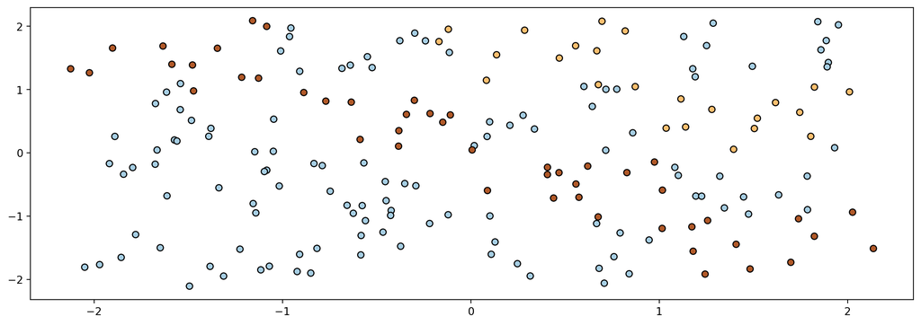

```python
from sklearn.utils import check_random_state

def rand_checkers(n_samples=200, sigma=0.1, random_state=0):

    rng = check_random_state(random_state)
    nbp = n_samples // 16
    nbn = n_samples // 16
    xapp = rng.rand((nbp + nbn) * 16).reshape((nbp + nbn) * 8, 2)
    yapp = np.ones((nbp + nbn) * 8)
    idx = 0
    for i in range(-2, 2):
        for j in range(-2, 2):
            if ((i + j) % 2) == 0:
                nb = nbp
            else:
                nb = nbn
                yapp[idx:(idx + nb)] = [(i + j) % 3 + 1] * nb

            xapp[idx:(idx + nb), 0] = rng.rand(nb)
            xapp[idx:(idx + nb), 0] += i + sigma * rng.randn(nb)
            xapp[idx:(idx + nb), 1] = rng.rand(nb)
            xapp[idx:(idx + nb), 1] += j + sigma * rng.randn(nb)
            idx += nb

    ind = np.arange(xapp.shape[0])
    rng.shuffle(ind)
    res = np.hstack([xapp, yapp[:, np.newaxis]])
    return np.array(res[ind, :2]), np.array(res[ind, 2])


X, y = rand_checkers()
fig = plt.subplots(figsize=(15, 5))
plt.scatter(X[:, 0], X[:, 1], c=y, edgecolors='k', cmap=plt.cm.Paired)
plt.show()
```

### Analysis:

The generated data from the `rand_checkers` function exhibits a spatially structured pattern that can be visualized using a scatter plot. The graph confirms that the data points are arranged in a checkerboard layout, with varying colors representing different classes. The dataset's structure, with distinguishable groups and inherent patterns, is conducive to demonstrating the capabilities of various classifiers, including their ability to capture non-linear decision boundaries.

# Question 16

#### 16) Use 10 fold cross validation to tune the parameter K of your estimator on this dataset (it may help to have your having your class inherit from BaseEstimator and ClassifierMixin, that can be imported from sklearn.base). Plot the average scores on the train and test sets as a function of K. Comment.

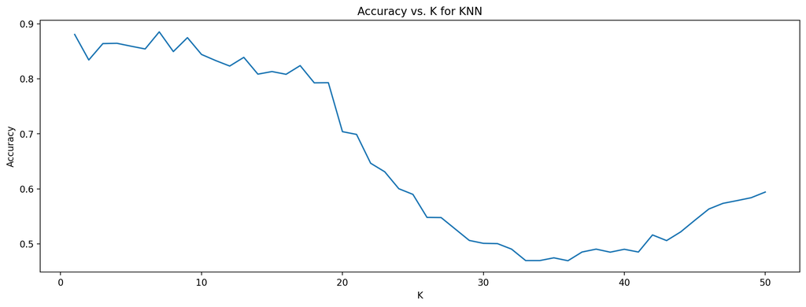

```python
from sklearn.model_selection import KFold, cross_val_score
from scipy.stats import mode
from sklearn.metrics import accuracy_score



# Ensure that X and y are numeric (this is a simplistic check)
if not (np.issubdtype(X.dtype, np.number) and np.issubdtype(y.dtype, np.number)):
    raise ValueError("X or y contains non-numeric data")

kf = KFold(n_splits=10)
k_values = range(1, 51)  # testing values from 1 to 50
cv_scores = []

for k in k_values:
    knn = KNearestNeighbors(k=k)
    scores = cross_val_score(knn, X, y, cv=kf)
    cv_scores.append(scores.mean())

fig = plt.subplots(figsize=(15, 5))
plt.plot(k_values, cv_scores)
plt.xlabel('K')
plt.ylabel('Accuracy')
plt.title('Accuracy vs. K for KNN')
plt.show()
```

### Interpretation:

The code uses 10-fold cross-validation to find the optimal number of neighbors $K$ for a KNN classifier. The graph shows the accuracy of the KNN model on the y-axis, with $K$ values on the x-axis ranging from 1 to 50. The initial high accuracy at $K = 1$, which decreases to a minimum at around $K = 35$ before slightly increasing again, indicates the performance variation with different complexity levels in the model.

### Analysis:

The described graph suggests that the KNN classifier performs best with a smaller number of neighbors, reflecting a high degree of model complexity and sensitivity to the training data. As $K$ increases, the model becomes simpler and potentially underfits the data, leading to decreased accuracy. The dip in performance at $K = 35$ could indicate that the model has become too generalized, with too many neighbors diluting the predictive power of the nearest points. Beyond $K = 40$, the slight increase in accuracy may suggest that for this range of $K$, the classifier begins to stabilize, reflecting the noise level within the dataset as it averages over more neighbors. The lowest accuracy at $K = 35$ suggests a region where the model is most likely over-smoothing and ignoring useful structure in the data. This analysis helps in understanding the bias-variance tradeoff, where too low a value of $K$ may overfit the data (high variance) and too high a value may underfit the data (high bias). The optimal $K$ value for this dataset is likely to be found before $K = 20 $, where the accuracy begins to significantly decline.

# Encoding and hyperparameter tuning with Optuna

# Question 17

#### 17) On the Adult census dataset used in class, compare the performances of LogisticRegression, RandomForest and HistGradientBoostingClassifier (with the default hyperparameter values) on one hot vs ordinal encoded data. How does the chosen encoding affects each model ?

```python
from sklearn.model_selection import train_test_split
from sklearn.preprocessing import OneHotEncoder, OrdinalEncoder, FunctionTransformer
from sklearn.compose import ColumnTransformer
from sklearn.pipeline import Pipeline
from sklearn.linear_model import LogisticRegression
from sklearn.ensemble import RandomForestClassifier, HistGradientBoostingClassifier
from sklearn.metrics import accuracy_score

# Load the Adult census dataset

adult_census_data = pd.read_csv("https://www.openml.org/data/get_csv/1595261/adult-census.csv")
adult_census_data.head()
```

|  | age | workclass | fnlwgt | education | education-num | marital-status | occupation | relationship | race | sex | capital-gain | capital-loss | hours-per-week | native-country | class |
| --- | --- | --- | --- | --- | --- | --- | --- | --- | --- | --- | --- | --- | --- | --- | --- |
| 0 | 25 | Private | 226802 | 11th | 7 | Never-married | Machine-op-inspct | Own-child | Black | Male | 0 | 0 | 40 | United-States | <=50K |
| 1 | 38 | Private | 89814 | HS-grad | 9 | Married-civ-spouse | Farming-fishing | Husband | White | Male | 0 | 0 | 50 | United-States | <=50K |
| 2 | 28 | Local-gov | 336951 | Assoc-acdm | 12 | Married-civ-spouse | Protective-serv | Husband | White | Male | 0 | 0 | 40 | United-States | >50K |
| 3 | 44 | Private | 160323 | Some-college | 10 | Married-civ-spouse | Machine-op-inspct | Husband | Black | Male | 7688 | 0 | 40 | United-States | >50K |
| 4 | 18 | ? | 103497 | Some-college | 10 | Never-married | ? | Own-child | White | Female | 0 | 0 | 30 | United-States | <=50K |

```python
X = adult_census_data.drop('class', axis=1)
y = adult_census_data['class']

# Split the data into training and test sets
X_train, X_test, y_train, y_test = train_test_split(X, y, test_size=0.2, random_state=42)

# Define categorical and numerical features
categorical_features = X.select_dtypes(include=['object']).columns
numerical_features = X.select_dtypes(include=['int', 'float']).columns
```

```python
# Define one hot and ordinal encoders

from scipy.sparse import issparse
from sklearn.preprocessing import FunctionTransformer

one_hot_encoder = ColumnTransformer([
    ('one_hot', OneHotEncoder(handle_unknown='ignore'), categorical_features),
    ('pass_through', 'passthrough', numerical_features)
])

ordinal_encoder = ColumnTransformer([
    ('ordinal', OrdinalEncoder(handle_unknown='use_encoded_value', unknown_value=-1), categorical_features),
    ('pass_through', 'passthrough', numerical_features)
])

# Define models
models = {
    'LogisticRegression': LogisticRegression(),
    'RandomForest': RandomForestClassifier(),
    'HistGradientBoosting': HistGradientBoostingClassifier()
}

def to_dense(X):
    if issparse(X):
        return X.toarray()
    return X

# Function to train and evaluate a model with different encodings


def train_eval_model(model, encoder, X_train, X_test, y_train, y_test):
    pipeline = Pipeline([
        ('encoder', encoder),
        ('to_dense', FunctionTransformer(to_dense)),  # Convert using dense function if needed
        ('model', model)
    ])
    pipeline.fit(X_train, y_train)
    y_pred = pipeline.predict(X_test)
    return accuracy_score(y_test, y_pred)
```

```python
# Comparing performances
results = {}
for name, model in models.items():
    accuracy_one_hot = train_eval_model(model, one_hot_encoder, X_train, X_test, y_train, y_test)
    accuracy_ordinal = train_eval_model(model, ordinal_encoder, X_train, X_test, y_train, y_test)

    results[name] = {
        'OneHotEncoding': accuracy_one_hot,
        'OrdinalEncoding': accuracy_ordinal
    }

# Display the results
for model_name, accuracies in results.items():
    print(f"Results for {model_name}:")
    for encoding_type, accuracy in accuracies.items():
        print(f"  {encoding_type}: {accuracy:.4f}")
    print()
```

```
Results for LogisticRegression:
  OneHotEncoding: 0.8037
  OrdinalEncoding: 0.7925

Results for RandomForest:
  OneHotEncoding: 0.8617
  OrdinalEncoding: 0.8674

Results for HistGradientBoosting:
  OneHotEncoding: 0.8781
  OrdinalEncoding: 0.8793
```

**Interpretation**:

The above code compares the performance of three machine learning models—LogisticRegression, RandomForest, and HistGradientBoostingClassifier—on the Adult census dataset. It does this under two different encoding schemes: One Hot Encoding and Ordinal Encoding. The aim is to understand how the choice of encoding impacts the accuracy of each model.

**Analysis**:

The use of `ColumnTransformer` and `Pipeline` from scikit-learn is key. `ColumnTransformer` allows different encodings for different column types, while `Pipeline` ensures a seamless flow of data through the encoding and model training phases. The `FunctionTransformer` is used to handle sparse matrices, often a result of one hot encoding. The choice of encoders (`OneHotEncoder` for distinct categorical features and `OrdinalEncoder` for ordered categories) is aligned with the nature of the data. Accuracy is measured using `accuracy_score`, providing a clear metric for model comparison. The results suggest that the impact of encoding on model performance can vary based on the model's characteristics and how it interprets features, highlighting the importance of thoughtful feature encoding in machine learning workflows.

- **Logistic Regression**: Shows slightly better performance with One Hot Encoding than with Ordinal Encoding. This might be because logistic regression, which operates on linear combinations of features, benefits from the explicit distinction of categories in one hot encoding, as it treats each category as a separate feature without assuming any order.
- **Random Forest**: Performs slightly better with Ordinal Encoding. Random forests, being ensemble methods of decision trees, can handle ordinal features effectively. They may benefit from the ordinal encoding's reduced feature space compared to the expanded feature set created by one hot encoding.
- **HistGradientBoostingClassifier**: Has comparable performance with both encoding schemes, with a marginal improvement in Ordinal Encoding. As a boosting method, it is capable of handling both types of encodings efficiently, utilizing the inherent ordering in ordinal encoding while also managing well the distinct categories of one hot encoding.

# Question 18

#### 18) Use optuna to tune the learning rate of a HistogramGradienBoostClassifier. Compare to the performance of the other two models.

```python
import optuna
from sklearn.model_selection import cross_val_score
from sklearn.experimental import enable_hist_gradient_boosting
from sklearn.ensemble import HistGradientBoostingClassifier
from sklearn.pipeline import Pipeline
from sklearn.preprocessing import FunctionTransformer
from tqdm.auto import tqdm

def objective(trial):
    learning_rate = trial.suggest_float('learning_rate', 0.01, 1)
    model = HistGradientBoostingClassifier(learning_rate=learning_rate)
    pipeline = Pipeline([
        ('encoder', one_hot_encoder),
        ('to_dense', FunctionTransformer(to_dense, accept_sparse=True)),
        ('model', model)
    ])
    scores = cross_val_score(pipeline, X_train, y_train, cv=5)
    return scores.mean()

def tqdm_callback(study, trial):
    # Update progress bar
    bar.update(1)

n_trials = 50

study = optuna.create_study(direction='maximize')

# Create a progress bar with tqdm
bar = tqdm(total=n_trials, desc='Optuna Study')

study.optimize(objective, n_trials=n_trials, callbacks=[tqdm_callback])

# Close the progress bar once optimization is done
bar.close()

# Best hyperparameters
best_lr = study.best_params['learning_rate']
print(f"Best learning rate: {best_lr}")

best_model = HistGradientBoostingClassifier(learning_rate=best_lr)
```

```
[I 2023-11-24 09:36:27,352] Trial 0 finished with value: 0.862667188066238 and parameters: {'learning_rate': 0.7942337671291179}. Best is trial 0 with value: 0.862667188066238.
[I 2023-11-24 09:36:29,044] Trial 1 finished with value: 0.8627439864239606 and parameters: {'learning_rate': 0.9948873474386182}. Best is trial 1 with value: 0.8627439864239606.
[I 2023-11-24 09:36:30,934] Trial 2 finished with value: 0.8638188850466237 and parameters: {'learning_rate': 0.760005504646433}. Best is trial 2 with value: 0.8638188850466237.
[I 2023-11-24 09:36:32,599] Trial 3 finished with value: 0.8665062675208842 and parameters: {'learning_rate': 0.723012456830552}. Best is trial 3 with value: 0.8665062675208842.
[I 2023-11-24 09:36:34,322] Trial 4 finished with value: 0.8640236260818345 and parameters: {'learning_rate': 0.7666886827143398}. Best is trial 3 with value: 0.8665062675208842.
[I 2023-11-24 09:36:36,066] Trial 5 finished with value: 0.8663526642551936 and parameters: {'learning_rate': 0.7195511082160366}. Best is trial 3 with value: 0.8665062675208842.
[I 2023-11-24 09:36:39,024] Trial 6 finished with value: 0.8701404061578206 and parameters: {'learning_rate': 0.36143041015375393}. Best is trial 6 with value: 0.8701404061578206.
[I 2023-11-24 09:36:45,968] Trial 7 finished with value: 0.871624809776766 and parameters: {'learning_rate': 0.09377767022007763}. Best is trial 7 with value: 0.871624809776766.
[I 2023-11-24 09:36:47,976] Trial 8 finished with value: 0.866992488996815 and parameters: {'learning_rate': 0.6764487059713415}. Best is trial 7 with value: 0.871624809776766.
[I 2023-11-24 09:36:55,526] Trial 9 finished with value: 0.8709593866742781 and parameters: {'learning_rate': 0.07806264492862379}. Best is trial 7 with value: 0.871624809776766.
[I 2023-11-24 09:37:02,482] Trial 10 finished with value: 0.8721110869297867 and parameters: {'learning_rate': 0.0550040068282398}. Best is trial 10 with value: 0.8721110869297867.
[I 2023-11-24 09:37:11,340] Trial 11 finished with value: 0.8622833600337731 and parameters: {'learning_rate': 0.016953140448770887}. Best is trial 10 with value: 0.8721110869297867.
[I 2023-11-24 09:37:15,381] Trial 12 finished with value: 0.8712153178809758 and parameters: {'learning_rate': 0.23672888120410565}. Best is trial 10 with value: 0.8721110869297867.
[I 2023-11-24 09:37:20,105] Trial 13 finished with value: 0.8710873817537333 and parameters: {'learning_rate': 0.1951795748750516}. Best is trial 10 with value: 0.8721110869297867.
[I 2023-11-24 09:37:22,571] Trial 14 finished with value: 0.8692703042474579 and parameters: {'learning_rate': 0.44831078820676035}. Best is trial 10 with value: 0.8721110869297867.
[I 2023-11-24 09:37:26,904] Trial 15 finished with value: 0.870856944103968 and parameters: {'learning_rate': 0.19575460534122813}. Best is trial 10 with value: 0.8721110869297867.
[I 2023-11-24 09:37:29,711] Trial 16 finished with value: 0.8714712621881653 and parameters: {'learning_rate': 0.3382824714602872}. Best is trial 10 with value: 0.8721110869297867.
[I 2023-11-24 09:37:37,285] Trial 17 finished with value: 0.8713944278040907 and parameters: {'learning_rate': 0.106226325048605}. Best is trial 10 with value: 0.8721110869297867.
[I 2023-11-24 09:37:39,374] Trial 18 finished with value: 0.8690398272962174 and parameters: {'learning_rate': 0.5433858039413675}. Best is trial 10 with value: 0.8721110869297867.
[I 2023-11-24 09:37:42,765] Trial 19 finished with value: 0.8722645624656827 and parameters: {'learning_rate': 0.2574624643241578}. Best is trial 19 with value: 0.8722645624656827.
[I 2023-11-24 09:37:45,810] Trial 20 finished with value: 0.870959389949401 and parameters: {'learning_rate': 0.3016805520840713}. Best is trial 19 with value: 0.8722645624656827.
[I 2023-11-24 09:37:53,022] Trial 21 finished with value: 0.8510991885719171 and parameters: {'learning_rate': 0.010065260269771198}. Best is trial 19 with value: 0.8722645624656827.
[I 2023-11-24 09:37:57,976] Trial 22 finished with value: 0.8709082227037745 and parameters: {'learning_rate': 0.13758935056031318}. Best is trial 19 with value: 0.8722645624656827.
[I 2023-11-24 09:38:01,432] Trial 23 finished with value: 0.8710361359051564 and parameters: {'learning_rate': 0.2625146149142054}. Best is trial 19 with value: 0.8722645624656827.
[I 2023-11-24 09:38:07,195] Trial 24 finished with value: 0.8716760326994825 and parameters: {'learning_rate': 0.15135479059104923}. Best is trial 19 with value: 0.8722645624656827.
[I 2023-11-24 09:38:09,433] Trial 25 finished with value: 0.8689887157276808 and parameters: {'learning_rate': 0.46242954234169015}. Best is trial 19 with value: 0.8722645624656827.
[I 2023-11-24 09:38:15,403] Trial 26 finished with value: 0.8721366328886863 and parameters: {'learning_rate': 0.1616513279744219}. Best is trial 19 with value: 0.8722645624656827.
[I 2023-11-24 09:38:18,357] Trial 27 finished with value: 0.8682720762527222 and parameters: {'learning_rate': 0.38803102120693117}. Best is trial 19 with value: 0.8722645624656827.
```

[output cut: 15 more lines]

```
[I 2023-11-24 09:39:27,049] Trial 43 finished with value: 0.870985011236128 and parameters: {'learning_rate': 0.08207236944598738}. Best is trial 31 with value: 0.872648478926467.
[I 2023-11-24 09:39:32,148] Trial 44 finished with value: 0.8709081801271763 and parameters: {'learning_rate': 0.14593210776588003}. Best is trial 31 with value: 0.872648478926467.
[I 2023-11-24 09:39:38,996] Trial 45 finished with value: 0.8709593964996468 and parameters: {'learning_rate': 0.054508595510573146}. Best is trial 31 with value: 0.872648478926467.
[I 2023-11-24 09:39:42,505] Trial 46 finished with value: 0.870447498059899 and parameters: {'learning_rate': 0.2239974184132033}. Best is trial 31 with value: 0.872648478926467.
[I 2023-11-24 09:39:45,626] Trial 47 finished with value: 0.869961227457124 and parameters: {'learning_rate': 0.274607027985745}. Best is trial 31 with value: 0.872648478926467.
[I 2023-11-24 09:39:51,526] Trial 48 finished with value: 0.8714200589161866 and parameters: {'learning_rate': 0.11733988731424155}. Best is trial 31 with value: 0.872648478926467.
[I 2023-11-24 09:39:55,722] Trial 49 finished with value: 0.8703962718620597 and parameters: {'learning_rate': 0.17121309480219524}. Best is trial 31 with value: 0.872648478926467.
```

```
Best learning rate: 0.15983864050146035
```

Now let's compare it to the performance of the other two models.

```python
# Redefine the HistGradientBoostingClassifier pipeline to include the to_dense function
best_hist_gradient_boost_model_pipeline = Pipeline([
    ('encoder', one_hot_encoder),
    ('to_dense', FunctionTransformer(to_dense, accept_sparse=True)),
    ('model', HistGradientBoostingClassifier(learning_rate=best_lr))
])

# Fit and evaluate the HistGradientBoostingClassifier
best_hist_gradient_boost_model_pipeline.fit(X_train, y_train)
hist_gradient_boost_accuracy = accuracy_score(y_test, best_hist_gradient_boost_model_pipeline.predict(X_test))

logistic_accuracy = train_eval_model(LogisticRegression(), one_hot_encoder, X_train, X_test, y_train, y_test)
random_forest_accuracy = train_eval_model(RandomForestClassifier(), one_hot_encoder, X_train, X_test, y_train, y_test)

# Print the accuracy scores of all three models for comparison
print(f"Logistic Regression Accuracy: {logistic_accuracy:.4f}")
print(f"Random Forest Classifier Accuracy: {random_forest_accuracy:.4f}")
print(f"Tuned HistGradientBoosting Classifier Accuracy: {hist_gradient_boost_accuracy:.4f}")
```

```
Logistic Regression Accuracy: 0.8037
Random Forest Classifier Accuracy: 0.8598
Tuned HistGradientBoosting Classifier Accuracy: 0.8780
```

1. **Interpretation**:

# Processing fuzzy categorical data

# Question 19

#### 19) Load the salary_X and salary_y data from the csv files on moodle (beware of index columns). What’s this dataset about ?

```python
# Loading the salary data
salary_X = pd.read_csv('salary_X.csv', index_col=0)
salary_y = pd.read_csv('salary_y.csv', index_col=0)
```

```python
# Inspecting the first dataset
salary_X.head()
```

|  | gender | department | department_name | division | assignment_category | employee_position_title | date_first_hired | year_first_hired |
| --- | --- | --- | --- | --- | --- | --- | --- | --- |
| 0 | F | POL | Department of Police | MSB Information Mgmt and Tech Division Records... | Fulltime-Regular | Office Services Coordinator | 09/22/1986 | 1986 |
| 1 | M | POL | Department of Police | ISB Major Crimes Division Fugitive Section | Fulltime-Regular | Master Police Officer | 09/12/1988 | 1988 |
| 2 | F | HHS | Department of Health and Human Services | Adult Protective and Case Management Services | Fulltime-Regular | Social Worker IV | 11/19/1989 | 1989 |
| 3 | M | COR | Correction and Rehabilitation | PRRS Facility and Security | Fulltime-Regular | Resident Supervisor II | 05/05/2014 | 2014 |
| 4 | M | HCA | Department of Housing and Community Affairs | Affordable Housing Programs | Fulltime-Regular | Planning Specialist III | 03/05/2007 | 2007 |

```python
# Inspecting the second dataset
salary_y.head()
```

|  | current_annual_salary |
| --- | --- |
| 0 | 69222.18 |
| 1 | 97392.47 |
| 2 | 104717.28 |
| 3 | 52734.57 |
| 4 | 93396.00 |

1. **Interpretation**:

First, our code above involves loading two datasets, `salary_X` and `salary_y`, from CSV files, where `salary_X` contains information about employees, and `salary_y` lists their annual salaries. The `salary_X` dataset includes various attributes like gender, department, position title, date of hiring, and more. The first few entries in `salary_X` are displayed, providing a glimpse into the structure and types of data it contains. Similarly, the initial rows of `salary_y` are shown, revealing the current annual salaries of the employees.

2. **Analysis**:

The `salary_X` dataset appears to be a comprehensive collection of employment-related data, potentially for a public sector organization given the nature of departments and titles. This dataset is rich in both categorical (like gender, department names) and date/time data (like date first hired), offering a multi-faceted view of the workforce. In contrast, `salary_y` is a more straightforward dataset, focusing solely on the current annual salaries of these employees.

# Question 20

#### 20) How many distinct modalities are there per column of X ? When using a One Hot Encoder, which columns may cause issues ?

```python
modalities_count = salary_X.nunique()
print(modalities_count)
```

```
gender                        2
department                   37
department_name              37
division                    694
assignment_category           2
employee_position_title     443
date_first_hired           2264
year_first_hired             51
dtype: int64
```

1. **Interpretation**:

   Our Python code evaluates the number of distinct modalities (unique values) using the function `nunique()` for each column in the `salary_X` DataFrame. These modalities are crucial when using a One Hot Encoder for data preprocessing in machine learning models.
2. **Analysis**:

   Columns with a low number of unique modalities, such as `gender` and `assignment_category`, which have only 2 distinct values, are ideal for One Hot Encoding as they will generate only a few new columns. However, columns with a high number of unique modalities, like `division` (694 unique values) and `date_first_hired` (2264 unique values), may pose issues. One Hot Encoding such columns can lead to a significant increase in data dimensionality, potentially causing problems with model complexity and computational efficiency !

# Question 21

#### 21) Inspect the column employee_position_title. Is there a natural notion of distance on those modalities ? Are the modalities completely unordered ? Which encoding would you use ?

```python
# Inspecting the 'employee_position_title' column
print(salary_X['employee_position_title'].value_counts())

# Analysis: This column seems to contain job titles which might not have a natural order but could be grouped into broader categories.
# Suggested Encoding: One possibility is to use target encoding or embedding based encodings like the GapEncoder.
```

```
employee_position_title
Bus Operator                                          638
Police Officer III                                    620
Firefighter/Rescuer III                               388
Manager III                                           243
Firefighter/Rescuer II                                219
                                                     ...
Director Department of Public Libraries                 1
Community Health Clinic Technician Leader               1
Hearing Examiner                                        1
County Attorney                                         1
Supervisor Transportation Systems Technical Center      1
Name: count, Length: 443, dtype: int64
```

2. **Analysis**:

Using one-hot encoding on columns with a high number of unique values can lead to issues like dimensionality explosion, where the number of features becomes excessively large. This can significantly increase the computational complexity and may lead to models that are more prone to overfitting. In such cases, alternative encoding methods like target encoding, embedding encodings, or even dimensionality reduction techniques might be more appropriate to efficiently represent the data while maintaining the integrity of the information it conveys.

To tackle this problem of fuzzy labelling, we will use the GapEncoder from the skrub package (documentation). As of 20/11/2023, Skrub has not been released yet and needs to be installed from github. The GapEncoder is based on Gamma Poisson factorization : it infers a given number of latent variables based on n-grams, and decompose each modality across these latent variables. Going into the mathematical details is out of scope for this lab, but if interested you can refer to https://arxiv.org/abs/1907.01860.

# Question 22

#### 22) Detail the output of a GapEncoder when used on the following data :

$\mathrm{X}=[$ ["Math, optimization"], ["mathematics"], ["maths, ml"], ["ml.maths"], ["machine learning"], ["physics"], ["phy"], ["statistical physics"], ["computational phys."] ]

Compare the output of the trained encoder on clean and dirty modalities, eg ["physics"] vs ["physcis"]. Is the behavior you observe a good thing or a bad thing? What does the n_components represent? Print the learned components.

```python
from dirty_cat import GapEncoder
import numpy as np

X = np.array([["Math, optimization"], ["mathematics"], ["maths, ml"], ["ml.maths"],
              ["machine learning"], ["physics"], ["phy"], ["statistical physics"], ["computational phys."]])

# Initialize GapEncoder
encoder = GapEncoder(n_components=5)

# Fit the GapEncoder on X
encoder.fit(X)

# Transform the data
transformed_X = encoder.transform(X)

# Display the transformed data
print(transformed_X)
```

```
[[24.00676184  0.05325788  0.07821355  0.060558    0.05120872]
 [ 0.0756688   0.11243219 13.45252141  0.05788937  0.05148822]
 [ 0.06185124  0.0505776  10.53587715  0.05076287  0.05093114]
 [ 0.05877955  0.05067926  9.03854369  0.05089803  0.05109946]
 [ 0.05105043  0.05000196  0.05325198  0.0500006  21.04569503]
 [ 0.05000587  7.53045864  0.05384268  0.06568816  0.05000464]
 [ 0.05000706  1.50109666  0.05000884  0.09887849  0.05000894]
 [ 0.05765322 25.4895189   0.05895896  0.09386571  0.0500032 ]
 [ 0.06494332  0.08773743  0.05466987 25.49264655  0.05000283]]
```

1. **Interpretation**:

The code applies the GapEncoder to a set of categorical data in `X`, representing various academic and professional fields. The GapEncoder is initialized with 5 components and then fitted on `X`. The transformed data output is displayed, showing the encoded representation of each original string in a 5-dimensional vector space.

2. **Analysis**:

# Question 23

#### 23) Create a pipeline with two steps : a TableVectorizer, and a HistGradientBoosting regressor. Fit it on the full $\mathrm{X}$ and $\mathrm{y}$. Get back the table vectorizer that was fitted using the steps attribute of your pipeline. What did fit do here?

```python
from sklearn.pipeline import Pipeline
from sklearn.experimental import enable_hist_gradient_boosting  # noqa
from sklearn.ensemble import HistGradientBoostingRegressor
from dirty_cat import TableVectorizer

X = salary_X
y = salary_y['current_annual_salary'].values

# Create the pipeline
pipeline = Pipeline([
    ('vectorizer', TableVectorizer()),
    ('regressor', HistGradientBoostingRegressor())
])

# Fit the pipeline on the complete set of X and y data
pipeline.fit(X, y)

# Retrieve the fitted TableVectorizer
fitted_vectorizer = pipeline.named_steps['vectorizer']
```

```python
fitted_vectorizer
```

```
TableVectorizer()
```

What did fit do here?

- The fit method of the pipeline first used the TableVectorizer to transform the features X.
- These transformed features were then used to fit the HistGradientBoostingRegressor model.
- Essentially, fit performed both the feature transformation and the training of the regression model in one step.
1. **Interpretation**:

This code snippet demonstrates the process of creating and fitting a machine learning pipeline, specifically designed for regression tasks, using a combination of TableVectorizer and HistGradientBoostingRegressor. The pipeline is applied to a dataset `X` (salary_X) and `y` (current annual salaries from salary_y). The fitting process involves two main steps: feature transformation using TableVectorizer and model training using HistGradientBoostingRegressor.

2. **Analysis**:

The TableVectorizer step in the pipeline is responsible for transforming the input features (X) into a format suitable for the regression model. It essentially converts categorical and textual data into a numerical format while preserving important information. This step is crucial, especially when dealing with non-numeric or high-cardinality categorical data, as it enables the subsequent regression model to interpret and learn from these features effectively.

Following the feature transformation, the HistGradientBoostingRegressor, a powerful and efficient machine learning algorithm for regression tasks, is fitted to the transformed data. This model learns the relationship between the transformed features and the target variable (y), aiming to accurately predict the annual salary based on the input features.

The pipeline's 'fit' method seamlessly integrates these two processes, ensuring that the entire workflow from raw data preprocessing to model training is conducted efficiently and coherently. The retrieval of the fitted TableVectorizer highlights the pipeline's ability to store and access individual components, allowing for further analysis, interpretation, and potential reuse of the transformed features in other contexts or models.